# Lab 3 SPSS Output

[output not shown]

Log  
Log - Log - September 19, 2018

GET  
FILE='C:\Users\Heather\OneDrive - Brock University\Masters\TA\BIOL3P96\2019\Lab 3\Lab 3 SPSS files\appendixd (2).sav'.  
DATASET NAME DataSet6 WINDOW=FRONT.  
* Chart Builder.  
GGRAPH  
/GRAPHDATASET NAME="graphdataset" VARIABLES=socprob COUNT()[name="COUNT"] MISSING=LISTWISE  
REPORTMISSING=NO  
/GRAPHSPEC SOURCE=INLINE.  
BEGIN GPL  
SOURCE: s=userSource(id("graphdataset"))  
DATA: socprob=col(source(s), name("socprob"), unit.category())  
DATA: COUNT=col(source(s), name("COUNT"))  
GUIDE: axis(dim(1), label("Social problems in 9th grade"))  
GUIDE: axis(dim(2), label("Count"))  
SCALE: cat(dim(1), include("0", "1"))  
SCALE: linear(dim(2), include(0))  
ELEMENT: interval(position(socprob*COUNT), shape.interior(shape.square))  
END GPL.

GGraph  
GGraph - Active Dataset - September 19, 2018

[DataSet6] C:\Users\Heather\OneDrive - Brock University\Masters\TA\BIOL3P96\2019\Lab 3\Lab 3 SPSS files\appendixd (2).sav

GGraph  
GGraph - Graph - September 19, 2018

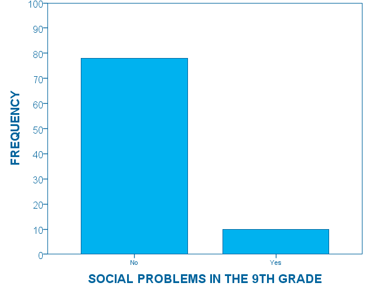

Log  
Log - Log - September 19, 2018

DATASET ACTIVATE DataSet6.  
DATASET CLOSE DataSet5.  
* Chart Builder.  
GGRAPH  
/GRAPHDATASET NAME="graphdataset" VARIABLES=socprob COUNT()[name="COUNT"] MISSING=LISTWISE  
REPORTMISSING=NO  
/GRAPHSPEC SOURCE=INLINE.  
BEGIN GPL  
SOURCE: s=userSource(id("graphdataset"))  
DATA: socprob=col(source(s), name("socprob"), unit.category())  
DATA: COUNT=col(source(s), name("COUNT"))  
GUIDE: axis(dim(1), label("Social problems in 9th grade"))  
GUIDE: axis(dim(2), label("Percent"))  
SCALE: cat(dim(1), include("0", "1"))  
SCALE: linear(dim(2), include(0))  
ELEMENT: interval(position(summary.percent(socprob*COUNT, base.all(acrossPanels()))),  
shape.interior(shape.square))  
END GPL.

GGraph  
GGraph - Graph - September 19, 2018

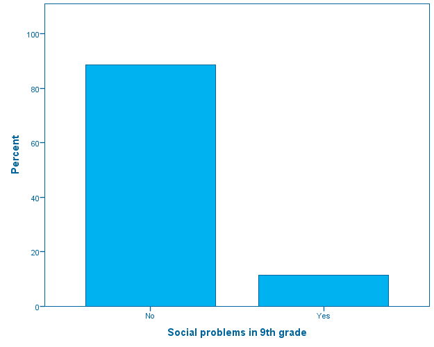

Log  
Log - Log - September 19, 2018

* Chart Builder.  
GGRAPH  
/GRAPHDATASET NAME="graphdataset" VARIABLES=gpa MISSING=LISTWISE REPORTMISSING=NO  
/GRAPHSPEC SOURCE=INLINE.  
BEGIN GPL  
SOURCE: s=userSource(id("graphdataset"))  
DATA: gpa=col(source(s), name("gpa"))  
GUIDE: axis(dim(1), label("GPA in 9th grade"))  
GUIDE: axis(dim(2), label("Frequency"))  
ELEMENT: interval(position(summary.count(bin.rect(gpa))), shape.interior(shape.square))  
END GPL.

GGraph  
GGraph - Graph - September 19, 2018

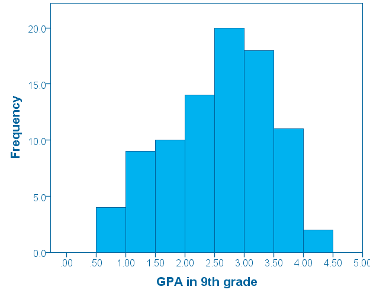

Log  
Log - Log - September 19, 2018

* Chart Builder.  
GGRAPH  
/GRAPHDATASET NAME="graphdataset" VARIABLES=dropout gpa MISSING=LISTWISE REPORTMISSING=NO  
/GRAPHSPEC SOURCE=INLINE.  
BEGIN GPL  
SOURCE: s=userSource(id("graphdataset"))  
DATA: dropout=col(source(s), name("dropout"), unit.category())  
DATA: gpa=col(source(s), name("gpa"))  
DATA: id=col(source(s), name("$CASENUM"), unit.category())  
GUIDE: axis(dim(1), label("Dropped out of high school"))  
GUIDE: axis(dim(2), label("GPA in 9th grade"))  
SCALE: cat(dim(1), include("0", "1"))  
SCALE: linear(dim(2), include(0))  
ELEMENT: schema(position(bin.quantile.letter(dropout*gpa)), label(id))  
END GPL.

GGraph  
GGraph - Graph - September 19, 2018

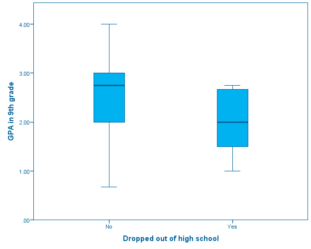

Log  
Log - Log - September 19, 2018

* Chart Builder.  
GGRAPH  
/GRAPHDATASET NAME="graphdataset" VARIABLES=sex gpa MISSING=LISTWISE REPORTMISSING=NO  
/GRAPHSPEC SOURCE=INLINE.  
BEGIN GPL  
SOURCE: s=userSource(id("graphdataset"))  
DATA: sex=col(source(s), name("sex"), unit.category())  
DATA: gpa=col(source(s), name("gpa"))  
DATA: id=col(source(s), name("$CASENUM"), unit.category())  
GUIDE: axis(dim(1), label("Gender"))  
GUIDE: axis(dim(2), label("GPA in 9th grade"))  
SCALE: cat(dim(1), include("1", "2"))  
SCALE: linear(dim(2), include(0))  
ELEMENT: schema(position(bin.quantile.letter(sex*gpa)), label(id))  
END GPL.

GGraph  
GGraph - Graph - September 19, 2018

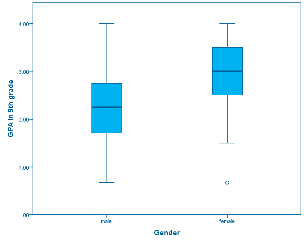

Log  
Log - Log - September 19, 2018

* Chart Builder.  
GGRAPH  
/GRAPHDATASET NAME="graphdataset" VARIABLES=dropout MEAN(gpa)[name="MEAN_gpa"] MISSING=LISTWISE  
REPORTMISSING=NO  
/GRAPHSPEC SOURCE=INLINE.  
BEGIN GPL  
SOURCE: s=userSource(id("graphdataset"))  
DATA: dropout=col(source(s), name("dropout"), unit.category())  
DATA: MEAN_gpa=col(source(s), name("MEAN_gpa"))  
GUIDE: axis(dim(1), label("Dropped out of high school"))  
GUIDE: axis(dim(2), label("Mean GPA in 9th grade"))  
SCALE: cat(dim(1), include("0", "1"))  
SCALE: linear(dim(2), include(0))  
ELEMENT: interval(position(dropout*MEAN_gpa), shape.interior(shape.square))  
END GPL.

GGraph  
GGraph - Graph - September 19, 2018

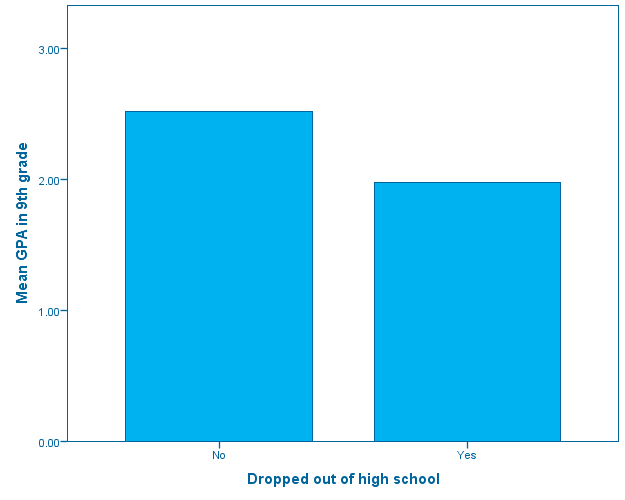

Log  
Log - Log - September 19, 2018

* Chart Builder.  
GGRAPH  
/GRAPHDATASET NAME="graphdataset" VARIABLES=sex COUNT()[name="COUNT"] dropout MISSING=LISTWISE  
REPORTMISSING=NO  
/GRAPHSPEC SOURCE=INLINE.  
BEGIN GPL  
SOURCE: s=userSource(id("graphdataset"))  
DATA: sex=col(source(s), name("sex"), unit.category())  
DATA: COUNT=col(source(s), name("COUNT"))  
DATA: dropout=col(source(s), name("dropout"), unit.category())  
COORD: rect(dim(1,2), cluster(3,0))  
GUIDE: axis(dim(3), label("Gender"))  
GUIDE: axis(dim(2), label("Count"))  
GUIDE: legend(aesthetic(aesthetic.color.interior), label("Dropped out of high school"))  
SCALE: cat(dim(3), include("1", "2"))  
SCALE: linear(dim(2), include(0))  
SCALE: cat(aesthetic(aesthetic.color.interior), include("0", "1"))  
SCALE: cat(dim(1), include("0", "1"))  
ELEMENT: interval(position(dropout*COUNT*sex), color.interior(dropout),  
shape.interior(shape.square))  
END GPL.

GGraph  
GGraph - Graph - September 19, 2018

[figure not shown]

Log  
Log - Log - September 19, 2018

* Chart Builder.  
GGRAPH  
/GRAPHDATASET NAME="graphdataset" VARIABLES=sex MEAN(gpa)[name="MEAN_gpa"] dropout  
MISSING=LISTWISE REPORTMISSING=NO  
/GRAPHSPEC SOURCE=INLINE.  
BEGIN GPL  
SOURCE: s=userSource(id("graphdataset"))  
DATA: sex=col(source(s), name("sex"), unit.category())  
DATA: MEAN_gpa=col(source(s), name("MEAN_gpa"))  
DATA: dropout=col(source(s), name("dropout"), unit.category())  
COORD: rect(dim(1,2), cluster(3,0))  
GUIDE: axis(dim(3), label("Gender"))  
GUIDE: axis(dim(2), label("Mean GPA in 9th grade"))  
GUIDE: legend(aesthetic(aesthetic.color.interior), label("Dropped out of high school"))  
SCALE: cat(dim(3), include("1", "2"))  
SCALE: linear(dim(2), include(0))  
SCALE: cat(aesthetic(aesthetic.color.interior), include("0", "1"))  
SCALE: cat(dim(1), include("0", "1"))  
ELEMENT: interval(position(dropout*MEAN_gpa*sex), color.interior(dropout),  
shape.interior(shape.square))  
END GPL.

GGraph  
GGraph - Graph - September 19, 2018

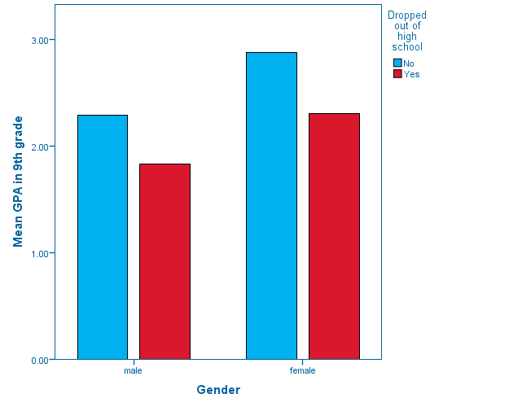

Log  
Log - Log - September 19, 2018

* Chart Builder.  
GGRAPH  
/GRAPHDATASET NAME="graphdataset" VARIABLES=iq gpa MISSING=LISTWISE REPORTMISSING=NO  
/GRAPHSPEC SOURCE=INLINE.  
BEGIN GPL  
SOURCE: s=userSource(id("graphdataset"))  
DATA: iq=col(source(s), name("iq"))  
DATA: gpa=col(source(s), name("gpa"))  
GUIDE: axis(dim(1), label("IQ score"))  
GUIDE: axis(dim(2), label("GPA in 9th grade"))  
ELEMENT: point(position(iq*gpa))  
END GPL.

GGraph  
GGraph - Graph - September 19, 2018

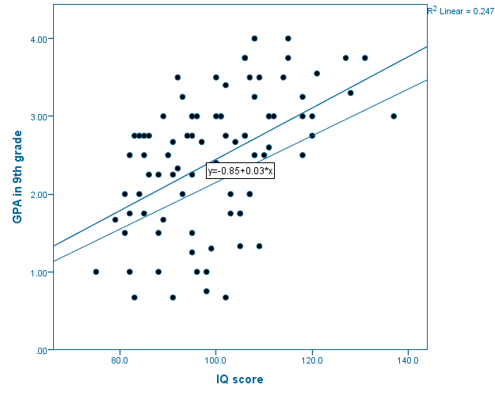

Log  
Log - Log - September 19, 2018

GET  
FILE='C:\Users\Heather\OneDrive - Brock University\Masters\TA\BIOL3P96\2019\Lab 3\Lab 3 SPSS files\Measles Outbreak.sav'.  
DATASET NAME DataSet7 WINDOW=FRONT.  
DATASET CLOSE DataSet6.  
* Chart Builder.  
GGRAPH  
/GRAPHDATASET NAME="graphdataset" VARIABLES=yearByQuarter  
MEAN(confirmedCases)[name="MEAN_confirmedCases"] MISSING=LISTWISE REPORTMISSING=NO  
/GRAPHSPEC SOURCE=INLINE.  
BEGIN GPL  
SOURCE: s=userSource(id("graphdataset"))  
DATA: yearByQuarter=col(source(s), name("yearByQuarter"))  
DATA: MEAN_confirmedCases=col(source(s), name("MEAN_confirmedCases"))  
GUIDE: axis(dim(1), label("Year by quarter"))  
GUIDE: axis(dim(2), label("Mean Number of new measles cases"))  
ELEMENT: line(position(yearByQuarter*MEAN_confirmedCases), missing.wings())  
END GPL.

GGraph  
GGraph - Graph - September 19, 2018

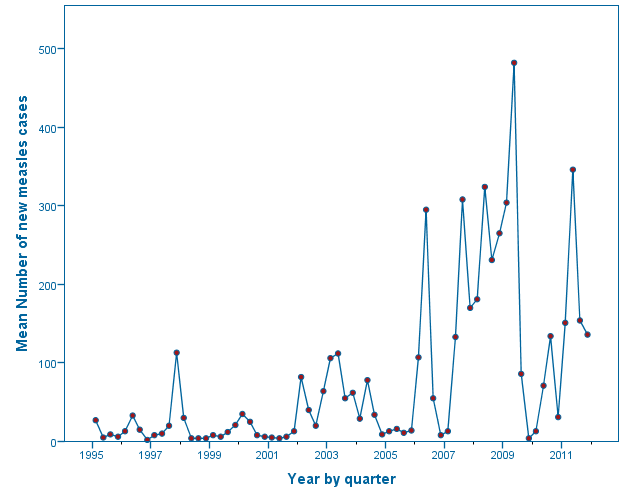

Log  
Log - Log - September 19, 2018

* Chart Builder.  
GGRAPH  
/GRAPHDATASET NAME="graphdataset" VARIABLES=yearByQuarter confirmedCases MISSING=LISTWISE  
REPORTMISSING=NO  
/GRAPHSPEC SOURCE=INLINE  
TEMPLATE=[  
"C:\Users\Heather\OneDrive - Brock University\Masters\TA\BIOL3P96\2019\Lab 3\Lab 3 SPSS "+  
"files\Chart template.sgt"].  
BEGIN GPL  
SOURCE: s=userSource(id("graphdataset"))  
DATA: yearByQuarter=col(source(s), name("yearByQuarter"))  
DATA: confirmedCases=col(source(s), name("confirmedCases"))  
GUIDE: axis(dim(1), label("Year by quarter"))  
GUIDE: axis(dim(2), label("Number of new measles cases"))  
ELEMENT: line(position(yearByQuarter*confirmedCases), missing.wings())  
END GPL.

GGraph  
GGraph - Graph - September 19, 2018

[figure not shown]

Log  
Log - Log - September 19, 2018

GET  
FILE='C:\Users\Heather\OneDrive - Brock University\Masters\TA\BIOL3P96\2019\Lab 3\Lab 3 SPSS files\appendixd (2).sav'.  
DATASET NAME DataSet8 WINDOW=FRONT.  
* Chart Builder.  
GGRAPH  
/GRAPHDATASET NAME="graphdataset" VARIABLES=dropout addsc sex MISSING=LISTWISE REPORTMISSING=NO  
/GRAPHSPEC SOURCE=INLINE.  
BEGIN GPL  
SOURCE: s=userSource(id("graphdataset"))  
DATA: dropout=col(source(s), name("dropout"), unit.category())  
DATA: addsc=col(source(s), name("addsc"))  
DATA: sex=col(source(s), name("sex"), unit.category())  
DATA: id=col(source(s), name("$CASENUM"), unit.category())  
COORD: rect(dim(1,2), cluster(3,0))  
GUIDE: axis(dim(3), label("Dropped out of high school"))  
GUIDE: axis(dim(2), label("ADD score"))  
GUIDE: legend(aesthetic(aesthetic.color), label("Gender"))  
SCALE: cat(dim(3), include("0", "1"))  
SCALE: linear(dim(2), include(0))  
SCALE: cat(aesthetic(aesthetic.color), include("1", "2"))  
SCALE: cat(dim(1), include("1", "2"))  
ELEMENT: schema(position(bin.quantile.letter(sex*addsc*dropout)), color(sex), label(id))  
END GPL.

GGraph  
GGraph - Active Dataset - September 19, 2018

[DataSet8] C:\Users\Heather\OneDrive - Brock University\Masters\TA\BIOL3P96\2019\Lab 3\Lab 3 SPSS files\appendixd (2).sav

GGraph  
GGraph - Graph - September 19, 2018

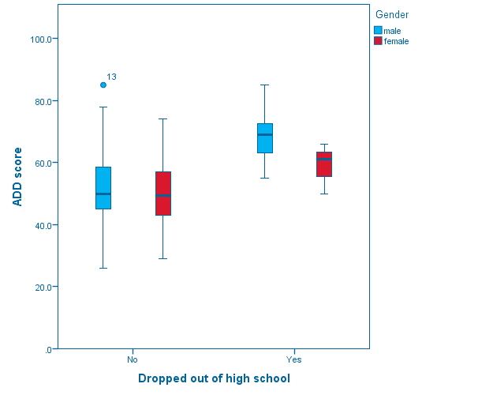

Log  
Log - Log - September 19, 2018

* Chart Builder.  
GGRAPH  
/GRAPHDATASET NAME="graphdataset" VARIABLES=breadth MISSING=LISTWISE REPORTMISSING=NO  
/GRAPHSPEC SOURCE=INLINE.  
BEGIN GPL  
SOURCE: s=userSource(id("graphdataset"))  
DATA: breadth=col(source(s), name("breadth"))  
GUIDE: axis(dim(1), label("breadth"))  
GUIDE: axis(dim(2), label("Frequency"))  
ELEMENT: interval(position(summary.count(bin.rect(breadth))), shape.interior(shape.square))  
END GPL.

GGraph  
GGraph - Graph - September 19, 2018

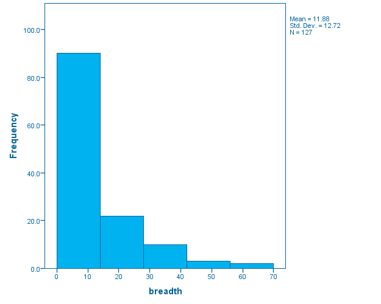

Log  
Log - Log - September 19, 2018

DATASET ACTIVATE DataSet8.  
DESCRIPTIVES VARIABLES=addsc iq engg gpa  
/STATISTICS=MEAN STDDEV VARIANCE SEMEAN.

Descriptives  
Descriptives - Active Dataset - September 19, 2018

[DataSet8] C:\Users\Heather\OneDrive - Brock University\Masters\TA\BIOL3P96\2019\Lab 3\Lab 3 SPSS files\appendixd (2).sav

Descriptives  
Descriptives - Descriptive Statistics - September 19, 2018

Descriptive StatisticsDescriptive Statistics, table, 2 levels of column headers and 1 levels of row headers, table with 6 columns and 8 rows

|  | N | Mean |  | Std. Deviation | Variance |
| --- | --- | --- | --- | --- | --- |
|  | Statistic | Statistic | Std. Error | Statistic | Statistic |
| ADD score | 88 | 52.60 | 1.32 | 12.42 | 154.31 |
| IQ score | 88 | 100.26 | 1.38 | 12.98 | 168.61 |
| English grade | 88 | 2.66 | .10 | .95 | .89 |
| GPA | 88 | 2.46 | .09 | .86 | .74 |
| Valid N (listwise) | 88 |  |  |  |  |

Log  
Log - Log - September 19, 2018

FREQUENCIES VARIABLES=addsc iq engg gpa  
/FORMAT=NOTABLE  
/NTILES=4  
/STATISTICS=STDDEV VARIANCE SEMEAN MEAN MEDIAN MODE  
/HISTOGRAM  
/ORDER=ANALYSIS.

Frequencies  
Frequencies - Statistics - September 19, 2018

StatisticsStatistics, table, 2 levels of column headers and 1 levels of row headers, table with 12 columns and 7 rows

|  | N |  | Mean | Std. Error of Mean | Median | Mode | Std. Deviation | Variance | Percentiles |  |  |
| --- | --- | --- | --- | --- | --- | --- | --- | --- | --- | --- | --- |
|  | Valid | Missing |  |  |  |  |  |  | 25 | 50 | 75 |
| ADD score | 88 | 0 | 52.602 | 1.3242 | 50.000 | 50.0 | 12.4222 | 154.311 | 44.250 | 50.000 | 60.750 |
| IQ score | 88 | 0 | 100.261 | 1.3842 | 100.000 | 95.0 | 12.9850 | 168.609 | 90.250 | 100.000 | 108.750 |
| Grade in 9th grade English class | 88 | 0 | 2.66 | .101 | 3.00 | 3 | .945 | .894 | 2.00 | 3.00 | 3.00 |
| GPA in 9th grade | 88 | 0 | 2.4563 | .09183 | 2.6350 | 3.00 | .86143 | .742 | 1.7500 | 2.6350 | 3.0000 |

Histogram  
Histogram - ADD score - September 19, 2018

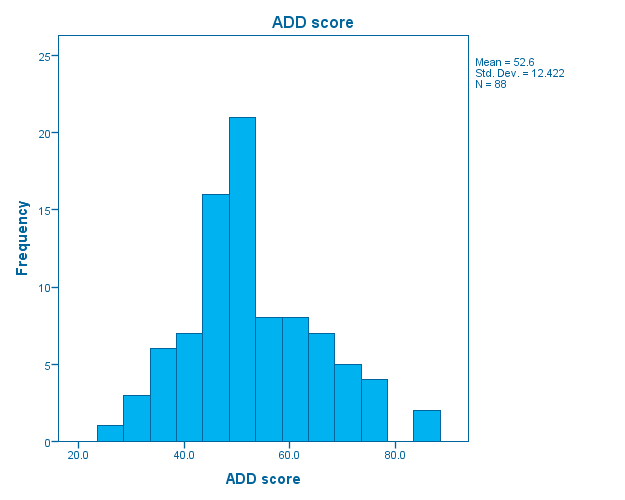

Histogram  
Histogram - IQ score - September 19, 2018

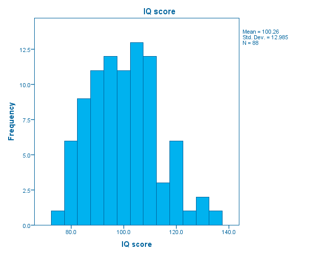

Histogram  
Histogram - Grade in 9th grade English class - September 19, 2018

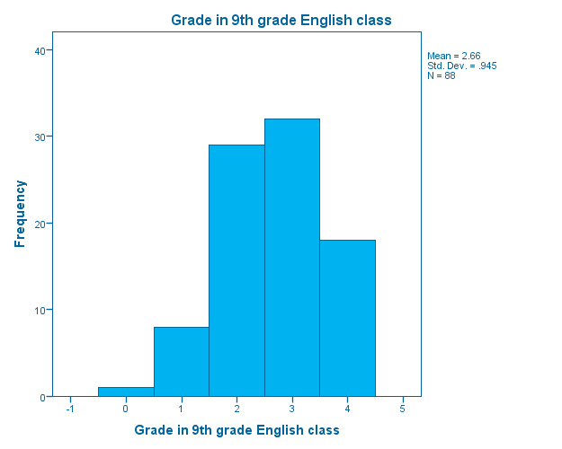

Histogram  
Histogram - GPA in 9th grade - September 19, 2018

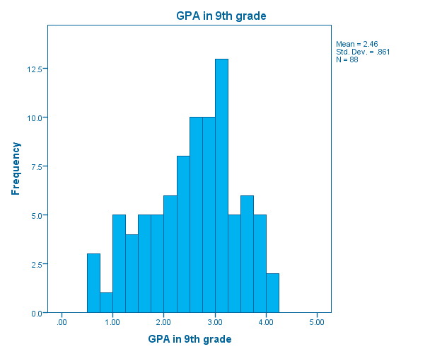

Log  
Log - Log - September 19, 2018

FREQUENCIES VARIABLES=sex repeat engl socprob dropout engg  
/BARCHART PERCENT  
/ORDER=ANALYSIS.

Frequencies  
Frequencies - Statistics - September 19, 2018

StatisticsStatistics, table, 1 levels of column headers and 2 levels of row headers, table with 8 columns and 4 rows

|  |  | Gender | Repeated grade | Level of English class taken in 9th grade | Social problems in 9th grade | Dropped out of high school | Grade in 9th grade English class |
| --- | --- | --- | --- | --- | --- | --- | --- |
| N | Valid | 88 | 88 | 88 | 88 | 88 | 88 |
|  | Missing | 0 | 0 | 0 | 0 | 0 | 0 |

Frequency Table  
Frequency Table - Gender - September 19, 2018

GenderGender, table, 1 levels of column headers and 2 levels of row headers, table with 6 columns and 5 rows

|  |  | Frequency | Percent | Valid Percent | Cumulative Percent |
| --- | --- | --- | --- | --- | --- |
| Valid | male | 55 | 62.5 | 62.5 | 62.5 |
|  | female | 33 | 37.5 | 37.5 | 100.0 |
|  | Total | 88 | 100.0 | 100.0 |  |

Frequency Table  
Frequency Table - Repeated grade - September 19, 2018

Repeated gradeRepeated grade, table, 1 levels of column headers and 2 levels of row headers, table with 6 columns and 5 rows

|  |  | Frequency | Percent | Valid Percent | Cumulative Percent |
| --- | --- | --- | --- | --- | --- |
| Valid | No | 76 | 86.4 | 86.4 | 86.4 |
|  | Yes | 12 | 13.6 | 13.6 | 100.0 |
|  | Total | 88 | 100.0 | 100.0 |  |

Frequency Table  
Frequency Table - Level of English class taken in 9th grade - September 19, 2018

Level of English class taken in 9th gradeLevel of English class taken in 9th grade, table, 1 levels of column headers and 2 levels of row headers, table with 6 columns and 6 rows

|  |  | Frequency | Percent | Valid Percent | Cumulative Percent |
| --- | --- | --- | --- | --- | --- |
| Valid | 1 | 14 | 15.9 | 15.9 | 15.9 |
|  | 2 | 64 | 72.7 | 72.7 | 88.6 |
|  | 3 | 10 | 11.4 | 11.4 | 100.0 |
|  | Total | 88 | 100.0 | 100.0 |  |

Frequency Table  
Frequency Table - Social problems in 9th grade - September 19, 2018

Social problems in 9th gradeSocial problems in 9th grade, table, 1 levels of column headers and 2 levels of row headers, table with 6 columns and 5 rows

|  |  | Frequency | Percent | Valid Percent | Cumulative Percent |
| --- | --- | --- | --- | --- | --- |
| Valid | No | 78 | 88.6 | 88.6 | 88.6 |
|  | Yes | 10 | 11.4 | 11.4 | 100.0 |
|  | Total | 88 | 100.0 | 100.0 |  |

Frequency Table  
Frequency Table - Dropped out of high school - September 19, 2018

Dropped out of high schoolDropped out of high school, table, 1 levels of column headers and 2 levels of row headers, table with 6 columns and 5 rows

|  |  | Frequency | Percent | Valid Percent | Cumulative Percent |
| --- | --- | --- | --- | --- | --- |
| Valid | No | 78 | 88.6 | 88.6 | 88.6 |
|  | Yes | 10 | 11.4 | 11.4 | 100.0 |
|  | Total | 88 | 100.0 | 100.0 |  |

Frequency Table  
Frequency Table - Grade in 9th grade English class - September 19, 2018

Grade in 9th grade English classGrade in 9th grade English class, table, 1 levels of column headers and 2 levels of row headers, table with 6 columns and 8 rows

|  |  | Frequency | Percent | Valid Percent | Cumulative Percent |
| --- | --- | --- | --- | --- | --- |
| Valid | E | 1 | 1.1 | 1.1 | 1.1 |
|  | D | 8 | 9.1 | 9.1 | 10.2 |
|  | C | 29 | 33.0 | 33.0 | 43.2 |
|  | B | 32 | 36.4 | 36.4 | 79.5 |
|  | A | 18 | 20.5 | 20.5 | 100.0 |
|  | Total | 88 | 100.0 | 100.0 |  |

Bar Chart  
Bar Chart - Gender - September 19, 2018

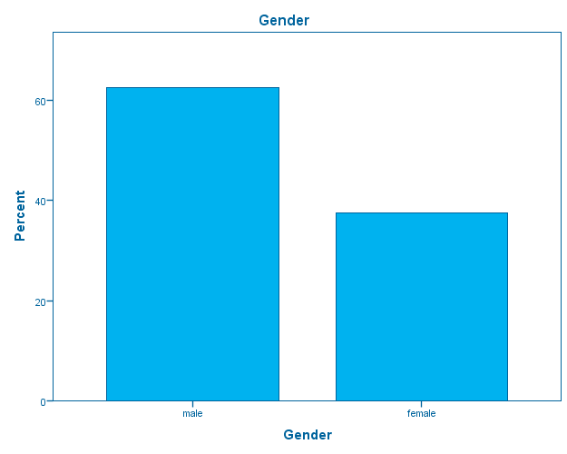

Bar Chart  
Bar Chart - Repeated grade - September 19, 2018

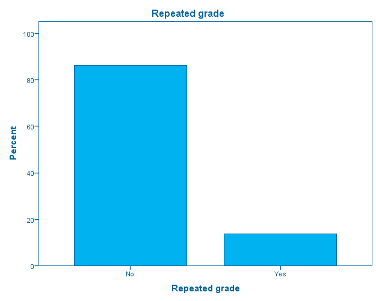

Bar Chart  
Bar Chart - Level of English class taken in 9th grade - September 19, 2018

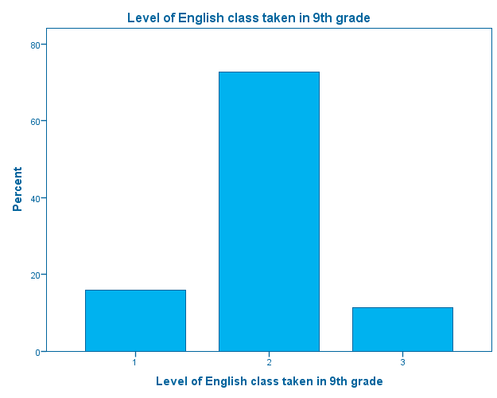

Bar Chart  
Bar Chart - Social problems in 9th grade - September 19, 2018

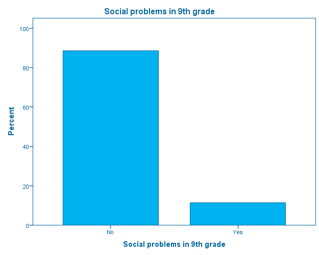

Bar Chart  
Bar Chart - Dropped out of high school - September 19, 2018

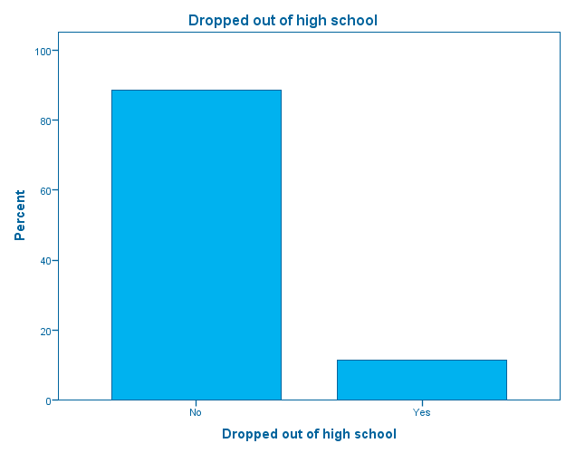

Bar Chart  
Bar Chart - Grade in 9th grade English class - September 19, 2018

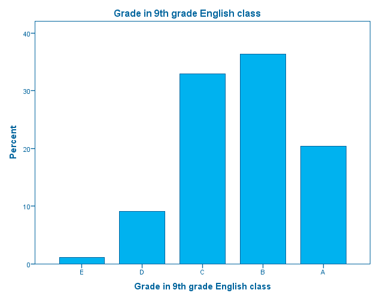

Log  
Log - Log - September 19, 2018

FREQUENCIES VARIABLES=engg  
/FORMAT=DVALUE  
/ORDER=ANALYSIS.

Frequencies  
Frequencies - Statistics - September 19, 2018

StatisticsStatistics, table, Grade in 9th grade English class, 1 layers, 0 levels of column headers and 2 levels of row headers, table with 3 columns and 4 rows

| Grade in 9th grade English class Grade in 9th grade English class |  |  |
| --- | --- | --- |
| N | Valid | 88 |
|  | Missing | 0 |

Frequencies  
Frequencies - Grade in 9th grade English class - September 19, 2018

Grade in 9th grade English classGrade in 9th grade English class, table, 1 levels of column headers and 2 levels of row headers, table with 6 columns and 8 rows

|  |  | Frequency | Percent | Valid Percent | Cumulative Percent |
| --- | --- | --- | --- | --- | --- |
| Valid | A | 18 | 20.5 | 20.5 | 20.5 |
|  | B | 32 | 36.4 | 36.4 | 56.8 |
|  | C | 29 | 33.0 | 33.0 | 89.8 |
|  | D | 8 | 9.1 | 9.1 | 98.9 |
|  | E | 1 | 1.1 | 1.1 | 100.0 |
|  | Total | 88 | 100.0 | 100.0 |  |

Log  
Log - Log - September 19, 2018

CROSSTABS  
/TABLES=socprob BY dropout  
/FORMAT=AVALUE TABLES  
/CELLS=COUNT ROW COLUMN TOTAL  
/COUNT ROUND CELL  
/BARCHART.

Crosstabs  
Crosstabs - Case Processing Summary - September 19, 2018

Case Processing SummaryCase Processing Summary, table, 3 levels of column headers and 1 levels of row headers, table with 7 columns and 5 rows

|  | Cases |  |  |  |  |  |
| --- | --- | --- | --- | --- | --- | --- |
|  | Valid |  | Missing |  | Total |  |
|  | N | Percent | N | Percent | N | Percent |
| Social problems in 9th grade * Dropped out of high school | 88 | 100.0% | 0 | 0.0% | 88 | 100.0% |

Crosstabs  
Crosstabs - Social problems in 9th grade * Dropped out of high school Crosstabulation - September 19(more), 2018(less)

Social problems in 9th grade * Dropped out of high school CrosstabulationSocial problems in 9th grade * Dropped out of high school Crosstabulation, table, 2 levels of column headers and 3 levels of row headers, table with 6 columns and 15 rows

|  |  |  | Dropped out of high school |  | Total |  |
| --- | --- | --- | --- | --- | --- | --- |
|  |  |  | No | Yes |  |  |
| Social problems in 9th grade | No | Count | 73 | 5 |  | 78 |
|  |  | % within Social problems in 9th grade | 93.6% | 6.4% | 100.0% |  |
|  |  | % within Dropped out of high school | 93.6% | 50.0% | 88.6% |  |
|  |  | % of Total | 83.0% | 5.7% | 88.6% |  |
|  | Yes | Count | 5 | 5 | 10 |  |
|  |  | % within Social problems in 9th grade | 50.0% | 50.0% | 100.0% |  |
|  |  | % within Dropped out of high school | 6.4% | 50.0% | 11.4% |  |
|  |  | % of Total | 5.7% | 5.7% | 11.4% |  |
| Total |  | Count | 78 | 10 | 88 |  |
|  |  | % within Social problems in 9th grade | 88.6% | 11.4% | 100.0% |  |
|  |  | % within Dropped out of high school | 100.0% | 100.0% | 100.0% |  |
|  |  | % of Total | 88.6% | 11.4% | 100.0% |  |

Crosstabs  
Crosstabs - Bar Chart - September 19, 2018

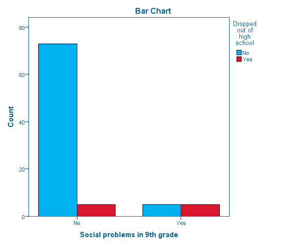

Log  
Log - Log - September 19, 2018

EXAMINE VARIABLES=iq  
/PLOT BOXPLOT HISTOGRAM  
/COMPARE GROUPS  
/STATISTICS DESCRIPTIVES  
/CINTERVAL 95  
/MISSING LISTWISE  
/NOTOTAL.

Explore  
Explore - Case Processing Summary - September 19, 2018

Case Processing SummaryCase Processing Summary, table, 3 levels of column headers and 1 levels of row headers, table with 7 columns and 5 rows

|  | Cases |  |  |  |  |  |
| --- | --- | --- | --- | --- | --- | --- |
|  | Valid |  | Missing |  | Total |  |
|  | N | Percent | N | Percent | N | Percent |
| IQ score | 88 | 100.0% | 0 | 0.0% | 88 | 100.0% |

Explore  
Explore - Descriptives - September 19, 2018

DescriptivesDescriptives, table, 1 levels of column headers and 3 levels of row headers, table with 5 columns and 15 rows

|  |  |  | Statistic | Std. Error |
| --- | --- | --- | --- | --- |
| IQ score | Mean |  | 100.261 | 1.3842 |
|  | 95% Confidence Interval for Mean | Lower Bound | 97.510 |  |
|  |  | Upper Bound | 103.013 |  |
|  | 5% Trimmed Mean |  | 99.783 |  |
|  | Median |  | 100.000 |  |
|  | Variance |  | 168.609 |  |
|  | Std. Deviation |  | 12.9850 |  |
|  | Minimum |  | 75.0 |  |
|  | Maximum |  | 137.0 |  |
|  | Range |  | 62.0 |  |
|  | Interquartile Range |  | 18.5 |  |
|  | Skewness |  | .394 | .257 |
|  | Kurtosis |  | -.163 | .508 |

IQ score  
IQ score - Histogram - September 19, 2018

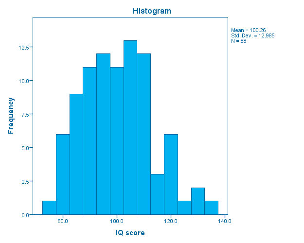

IQ score  
IQ score - Boxplot - September 19, 2018

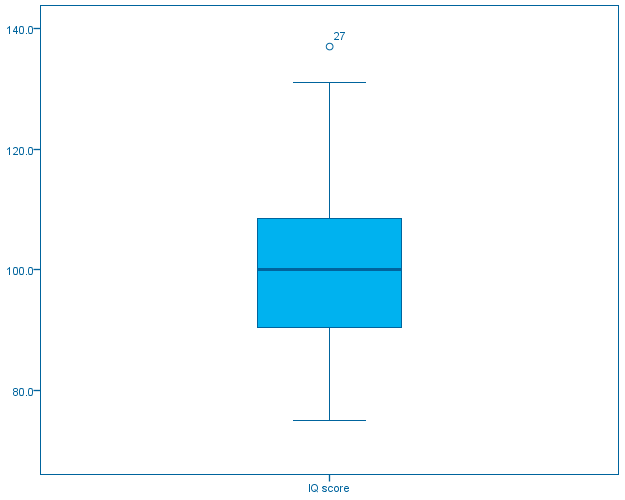

Log  
Log - Log - September 19, 2018

EXAMINE VARIABLES=iq BY sex  
/PLOT BOXPLOT HISTOGRAM  
/COMPARE GROUPS  
/STATISTICS DESCRIPTIVES  
/CINTERVAL 95  
/MISSING LISTWISE  
/NOTOTAL.

Gender  
Gender - Case Processing Summary - September 19, 2018

Case Processing SummaryCase Processing Summary, table, 3 levels of column headers and 2 levels of row headers, table with 8 columns and 6 rows

|  | Gender | Cases |  |  |  |  |  |
| --- | --- | --- | --- | --- | --- | --- | --- |
|  |  | Valid |  | Missing |  | Total |  |
|  |  | N | Percent | N | Percent | N | Percent |
| IQ score | male | 55 | 100.0% | 0 | 0.0% | 55 | 100.0% |
|  | female | 33 | 100.0% | 0 | 0.0% | 33 | 100.0% |

Gender  
Gender - Descriptives - September 19, 2018

DescriptivesDescriptives, table, 1 levels of column headers and 4 levels of row headers, table with 6 columns and 28 rows

|  | Gender |  |  | Statistic | Std. Error |
| --- | --- | --- | --- | --- | --- |
| IQ score | male | Mean |  | 99.327 | 1.7789 |
|  |  | 95% Confidence Interval for Mean | Lower Bound | 95.761 |  |
|  |  |  | Upper Bound | 102.894 |  |
|  |  | 5% Trimmed Mean |  | 98.793 |  |
|  |  | Median |  | 99.000 |  |
|  |  | Variance |  | 174.039 |  |
|  |  | Std. Deviation |  | 13.1924 |  |
|  |  | Minimum |  | 75.0 |  |
|  |  | Maximum |  | 137.0 |  |
|  |  | Range |  | 62.0 |  |
|  |  | Interquartile Range |  | 20.0 |  |
|  |  | Skewness |  | .451 | .322 |
|  |  | Kurtosis |  | .224 | .634 |
|  | female | Mean |  | 101.818 | 2.2068 |
|  |  | 95% Confidence Interval for Mean | Lower Bound | 97.323 |  |
|  |  |  | Upper Bound | 106.313 |  |
|  |  | 5% Trimmed Mean |  | 101.409 |  |
|  |  | Median |  | 100.000 |  |
|  |  | Variance |  | 160.716 |  |
|  |  | Std. Deviation |  | 12.6774 |  |
|  |  | Minimum |  | 83.0 |  |
|  |  | Maximum |  | 128.0 |  |
|  |  | Range |  | 45.0 |  |
|  |  | Interquartile Range |  | 20.0 |  |
|  |  | Skewness |  | .354 | .409 |
|  |  | Kurtosis |  | -.731 | .798 |

Histograms  
Histograms - sex= male - September 19, 2018

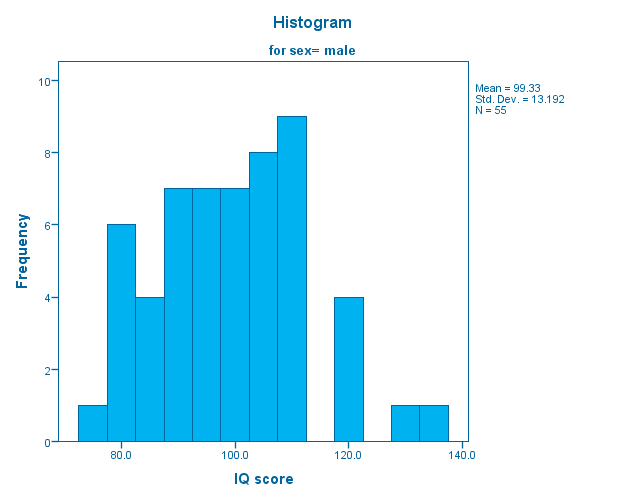

Histograms  
Histograms - sex= female - September 19, 2018

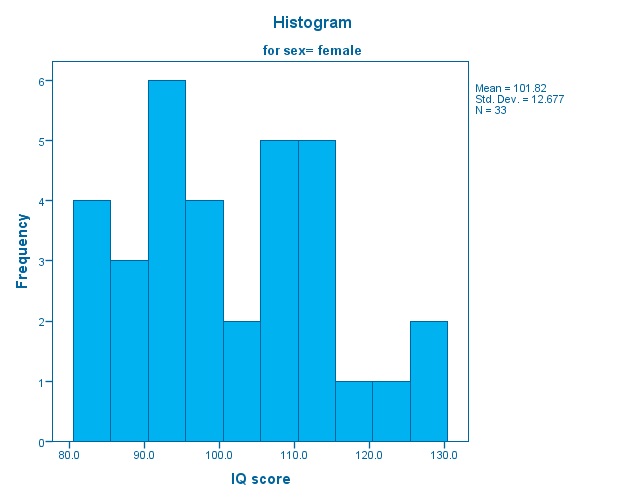

IQ score  
IQ score - Boxplot - September 19, 2018

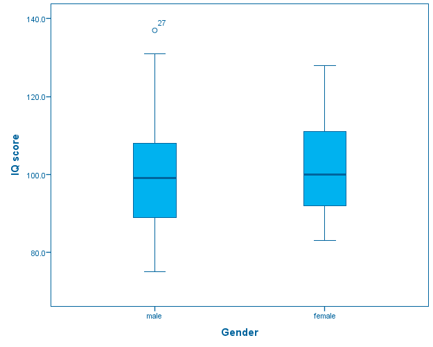

Log  
Log - Log - September 19, 2018

MEANS TABLES=addsc BY sex  
/CELLS=MEAN COUNT STDDEV SEMEAN.

Means  
Means - Case Processing Summary - September 19, 2018

Case Processing SummaryCase Processing Summary, table, 3 levels of column headers and 1 levels of row headers, table with 7 columns and 5 rows

|  | Cases |  |  |  |  |  |
| --- | --- | --- | --- | --- | --- | --- |
|  | Included |  | Excluded |  | Total |  |
|  | N | Percent | N | Percent | N | Percent |
| ADD score * Gender | 88 | 100.0% | 0 | 0.0% | 88 | 100.0% |

Means  
Means - Report - September 19, 2018

ReportReport, table, ADD score, 1 layers, 1 levels of column headers and 1 levels of row headers, table with 5 columns and 6 rows

| ADD score ADD score |  |  |  |  |
| --- | --- | --- | --- | --- |
| Gender | Mean | N | Std. Deviation | Std. Error of Mean |
| male | 54.291 | 55 | 12.9023 | 1.7397 |
| female | 49.788 | 33 | 11.2048 | 1.9505 |
| Total | 52.602 | 88 | 12.4222 | 1.3242 |

Log  
Log - Log - September 19, 2018

MEANS TABLES=addsc BY sex BY socprob  
/CELLS=MEAN COUNT STDDEV SEMEAN.

Means  
Means - Case Processing Summary - September 19, 2018

Case Processing SummaryCase Processing Summary, table, 3 levels of column headers and 1 levels of row headers, table with 7 columns and 5 rows

|  | Cases |  |  |  |  |  |
| --- | --- | --- | --- | --- | --- | --- |
|  | Included |  | Excluded |  | Total |  |
|  | N | Percent | N | Percent | N | Percent |
| ADD score * Gender * Social problems in 9th grade | 88 | 100.0% | 0 | 0.0% | 88 | 100.0% |

Means  
Means - Report - September 19, 2018

ReportReport, table, ADD score, 1 layers, 1 levels of column headers and 2 levels of row headers, table with 6 columns and 12 rows

| ADD score ADD score |  |  |  |  |  |
| --- | --- | --- | --- | --- | --- |
| Gender | Social problems in 9th grade | Mean | N | Std. Deviation | Std. Error of Mean |
| male | No | 52.250 | 48 | 11.6135 | 1.6763 |
|  | Yes | 68.286 | 7 | 13.4129 | 5.0696 |
|  | Total | 54.291 | 55 | 12.9023 | 1.7397 |
| female | No | 48.900 | 30 | 11.1830 | 2.0417 |
|  | Yes | 58.667 | 3 | 8.0829 | 4.6667 |
|  | Total | 49.788 | 33 | 11.2048 | 1.9505 |
| Total | No | 50.962 | 78 | 11.4941 | 1.3015 |
|  | Yes | 65.400 | 10 | 12.4918 | 3.9502 |
|  | Total | 52.602 | 88 | 12.4222 | 1.3242 |

Log  
Log - Log - September 19, 2018

GET DATA /TYPE=XLSX  
/FILE='C:\Users\Heather\OneDrive - Brock University\Masters\TA\BIOL3P96\2019\Lab 3\Lab 3 SPSS files\caffeine.xlsx'  
/SHEET=name 'caffeine'  
/CELLRANGE=full  
/READNAMES=on  
/ASSUMEDSTRWIDTH=32767.  
EXECUTE.  
DATASET NAME DataSet11 WINDOW=FRONT.  
EXAMINE VARIABLES=Caffeinemgin16oz.coffee  
/PLOT NONE  
/STATISTICS DESCRIPTIVES  
/CINTERVAL 95  
/MISSING LISTWISE  
/NOTOTAL.

Explore  
Explore - Active Dataset - September 19, 2018

[DataSet11]

Explore  
Explore - Case Processing Summary - September 19, 2018

Case Processing SummaryCase Processing Summary, table, 3 levels of column headers and 1 levels of row headers, table with 7 columns and 5 rows

|  | Cases |  |  |  |  |  |
| --- | --- | --- | --- | --- | --- | --- |
|  | Valid |  | Missing |  | Total |  |
|  | N | Percent | N | Percent | N | Percent |
| Caffeine (mg) in 16 oz. coffee | 14 | 100.0% | 0 | 0.0% | 14 | 100.0% |

Explore  
Explore - Descriptives - September 19, 2018

DescriptivesDescriptives, table, 1 levels of column headers and 3 levels of row headers, table with 5 columns and 15 rows

|  |  |  | Statistic | Std. Error |
| --- | --- | --- | --- | --- |
| Caffeine (mg) in 16 oz. coffee | Mean |  | 188.064 | 9.5079 |
|  | 95% Confidence Interval for Mean | Lower Bound | 167.524 |  |
|  |  | Upper Bound | 208.605 |  |
|  | 5% Trimmed Mean |  | 186.588 |  |
|  | Median |  | 176.250 |  |
|  | Variance |  | 1265.606 |  |
|  | Std. Deviation |  | 35.5754 |  |
|  | Minimum |  | 143.4 |  |
|  | Maximum |  | 259.3 |  |
|  | Range |  | 115.9 |  |
|  | Interquartile Range |  | 48.4 |  |
|  | Skewness |  | .792 | .597 |
|  | Kurtosis |  | -.274 | 1.154 |

Log  
Log - Log - September 19, 2018

* Chart Builder.  
GGRAPH  
/GRAPHDATASET NAME="graphdataset" VARIABLES=Caffeinemgin16oz.coffee[name=  
"Caffeinemgin16oz_coffee"] MISSING=LISTWISE REPORTMISSING=NO  
/GRAPHSPEC SOURCE=INLINE.  
BEGIN GPL  
SOURCE: s=userSource(id("graphdataset"))  
DATA: Caffeinemgin16oz_coffee=col(source(s), name("Caffeinemgin16oz_coffee"))  
GUIDE: axis(dim(1), label("Caffeine (mg) in 16 oz. coffee"))  
GUIDE: axis(dim(2), label("Frequency"))  
ELEMENT: interval(position(summary.count(bin.rect(Caffeinemgin16oz_coffee))),  
shape.interior(shape.square))  
END GPL.

GGraph  
GGraph - Graph - September 19, 2018

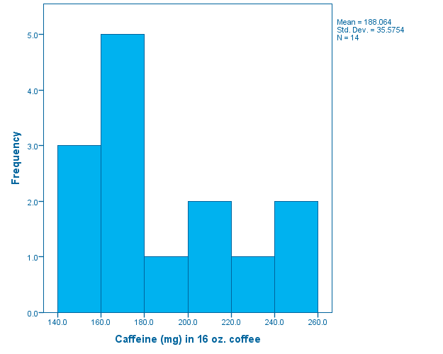

Log  
Log - Log - September 19, 2018

GET DATA /TYPE=XLSX  
/FILE='C:\Users\Heather\OneDrive - Brock University\Masters\TA\BIOL3P96\2019\Lab 3\Lab 3 SPSS files\caffeine-Starbucks (1).xlsx'  
/SHEET=name 'caffeine-Starbucks'  
/CELLRANGE=full  
/READNAMES=on  
/ASSUMEDSTRWIDTH=32767.  
EXECUTE.  
DATASET NAME DataSet12 WINDOW=FRONT.  
DESCRIPTIVES VARIABLES=Caffeinemgin16oz.coffee  
/STATISTICS=MEAN SEMEAN.

Descriptives  
Descriptives - Active Dataset - September 19, 2018

[DataSet12]

Descriptives  
Descriptives - Descriptive Statistics - September 19, 2018

Descriptive StatisticsDescriptive Statistics, table, 2 levels of column headers and 1 levels of row headers, table with 4 columns and 5 rows

|  | N | Mean |  |
| --- | --- | --- | --- |
|  | Statistic | Statistic | Std. Error |
| Caffeine (mg) in 16 oz. coffee | 6 | 371.967 | 51.5891 |
| Valid N (listwise) | 6 |  |  |

Log  
Log - Log - September 19, 2018

GET DATA /TYPE=XLSX  
/FILE='C:\Users\Heather\OneDrive - Brock University\Masters\TA\BIOL3P96\2019\Lab 3\Lab 3 SPSS files\Hemoglobin (1).xlsx'  
/SHEET=name 'chap02e3cHumanHemoglobinElevati'  
/CELLRANGE=full  
/READNAMES=on  
/ASSUMEDSTRWIDTH=32767.  
EXECUTE.  
DATASET NAME DataSet13 WINDOW=FRONT.  
EXAMINE VARIABLES=hemoglobin BY population  
/PLOT BOXPLOT  
/COMPARE GROUPS  
/STATISTICS DESCRIPTIVES  
/CINTERVAL 95  
/MISSING LISTWISE  
/NOTOTAL.

Explore  
Explore - Active Dataset - September 19, 2018

[DataSet13]

population  
population - Case Processing Summary - September 19, 2018

Case Processing SummaryCase Processing Summary, table, 3 levels of column headers and 2 levels of row headers, table with 8 columns and 8 rows

|  | population | Cases |  |  |  |  |  |
| --- | --- | --- | --- | --- | --- | --- | --- |
|  |  | Valid |  | Missing |  | Total |  |
|  |  | N | Percent | N | Percent | N | Percent |
| hemoglobin | Andes | 71 | 100.0% | 0 | 0.0% | 71 | 100.0% |
|  | Ethiopia | 128 | 100.0% | 0 | 0.0% | 128 | 100.0% |
|  | Tibet | 59 | 100.0% | 0 | 0.0% | 59 | 100.0% |
|  | USA | 1704 | 100.0% | 0 | 0.0% | 1704 | 100.0% |

population  
population - Descriptives - September 19, 2018

DescriptivesDescriptives, table, 1 levels of column headers and 4 levels of row headers, table with 6 columns and 54 rows

|  | population |  |  | Statistic | Std. Error |
| --- | --- | --- | --- | --- | --- |
| hemoglobin | Andes | Mean |  | 19.2310 | .21597 |
|  |  | 95% Confidence Interval for Mean | Lower Bound | 18.8002 |  |
|  |  |  | Upper Bound | 19.6617 |  |
|  |  | 5% Trimmed Mean |  | 19.1984 |  |
|  |  | Median |  | 19.1100 |  |
|  |  | Variance |  | 3.312 |  |
|  |  | Std. Deviation |  | 1.81981 |  |
|  |  | Minimum |  | 14.96 |  |
|  |  | Maximum |  | 25.06 |  |
|  |  | Range |  | 10.10 |  |
|  |  | Interquartile Range |  | 2.21 |  |
|  |  | Skewness |  | .432 | .285 |
|  |  | Kurtosis |  | .948 | .563 |
|  | Ethiopia | Mean |  | 15.8617 | .11222 |
|  |  | 95% Confidence Interval for Mean | Lower Bound | 15.6397 |  |
|  |  |  | Upper Bound | 16.0838 |  |
|  |  | 5% Trimmed Mean |  | 15.8564 |  |
|  |  | Median |  | 15.8400 |  |
|  |  | Variance |  | 1.612 |  |
|  |  | Std. Deviation |  | 1.26963 |  |
|  |  | Minimum |  | 12.65 |  |
|  |  | Maximum |  | 18.85 |  |
|  |  | Range |  | 6.20 |  |
|  |  | Interquartile Range |  | 1.81 |  |
|  |  | Skewness |  | .044 | .214 |
|  |  | Kurtosis |  | -.322 | .425 |
|  | Tibet | Mean |  | 15.7095 | .19546 |
|  |  | 95% Confidence Interval for Mean | Lower Bound | 15.3182 |  |
|  |  |  | Upper Bound | 16.1008 |  |
|  |  | 5% Trimmed Mean |  | 15.6326 |  |
|  |  | Median |  | 15.5300 |  |
|  |  | Variance |  | 2.254 |  |
|  |  | Std. Deviation |  | 1.50138 |  |
|  |  | Minimum |  | 13.03 |  |
|  |  | Maximum |  | 19.96 |  |
|  |  | Range |  | 6.93 |  |
|  |  | Interquartile Range |  | 1.59 |  |
|  |  | Skewness |  | .687 | .311 |
|  |  | Kurtosis |  | .949 | .613 |
|  | USA | Mean |  | 15.3808 | .02350 |
|  |  | 95% Confidence Interval for Mean | Lower Bound | 15.3347 |  |
|  |  |  | Upper Bound | 15.4269 |  |
|  |  | 5% Trimmed Mean |  | 15.3910 |  |
|  |  | Median |  | 15.4000 |  |
|  |  | Variance |  | .941 |  |
|  |  | Std. Deviation |  | .96988 |  |
|  |  | Minimum |  | 10.40 |  |
|  |  | Maximum |  | 18.65 |  |
|  |  | Range |  | 8.25 |  |
|  |  | Interquartile Range |  | 1.25 |  |
|  |  | Skewness |  | -.255 | .059 |
|  |  | Kurtosis |  | .933 | .119 |

hemoglobin  
hemoglobin - Boxplot - September 19, 2018

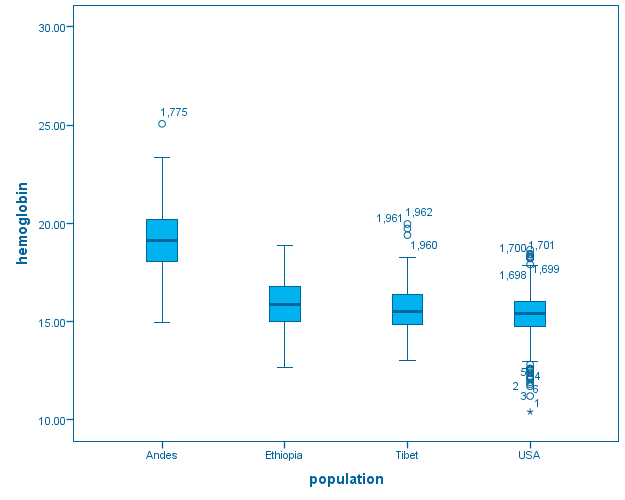

Log  
Log - Log - September 19, 2018

DATASET ACTIVATE DataSet7.  
DATASET CLOSE DataSet13.  
DATASET ACTIVATE DataSet8.  
DATASET CLOSE DataSet7.  
DATASET ACTIVATE DataSet9.  
DATASET CLOSE DataSet8.  
DATASET ACTIVATE DataSet11.  
DATASET CLOSE DataSet9.  
DATASET ACTIVATE DataSet12.  
DATASET CLOSE DataSet11.

Created Using: IBM SPSS Statistics 23

Creation Date: Sep 19, 2018

Document Version: Original

Saved Date: Sep 19, 2018

Help - Opens Help

Toolbar Buttons

[output not shown]

Connecting to a Server

Editing Tables

[output not shown]

Editing Charts

[output not shown]

Save

Server Connection

Status

Add a chart

Pivot and Sort

Chart Size

[output not shown]

Background

Line and Borders

Text Format

Number Format

[output not shown]

Axis Options

[output not shown]